# Paper Replication Report

For the project of *Cell Death Model*, we started replicating the rates for pyroptosis response using the paper:

[figure not shown]

## Biological diagram

Based on the *Workflow for Developing Mechanism-Based Computational Biology Models*, we first need to follow the conceptual biological model diagram to understand the underlying mechanism of the pathway leading to a pyroptotic response. The paper presented us with the following:

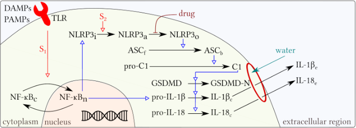

In summary, the main trigger for the pathway in this model is a Toll-like receptor that sends a binary signal indicating the presence of the Damp/Pamp molecule in the extracellular environment. This first signal is responsible for the production of inactive NLRP3 thru the transcription of NF-$\kappa$B. The NLRP3 needs a stimulus like altered calcium signaling, ROS, or potassium efflux to become active (1), indicated in the diagram by the red arrow S2 again; another binary function was chosen to represent this activation. The activation of NLRP3 leads to a cascade of events leading up to the formation of GSDMD-N, which is responsible for the characteristic holes in the cell membrane observed in pyroptotic death. NF-$\kappa$B is also responsible for promoting pro-IL-1$\beta$, which, in the cascade of events started by NLRP3, is transformed into its mature form IL-1$\beta$. This molecule is an inflammatory cytokine that recruits immune cells to the site and initiates pyroptosis in cells in the vicinity. The holes formed by the GSDMD-N release cytokines molecules outside the cell, but this measure also allows the influx of water inside, leading to the swelling of the cell and the rupture of the membrane and consequently cell death. Note that here we are deliberatively ignoring the drug treatment that stops the cascading of events since our goal is to represent the death of the cell.

$^{1} \text{ }_{\text{Bertinaria, M., Gastaldi, S., Marini, E. & Giorgis, M. (2019) Development of covalent NLRP3 inflammasome inhibitors:}}$ $_{\text{Chemistry and biological activity. Arch Biochem Biophys. 2019 Jul 30;670:116-139. doi: 10.1016/j.abb.2018.11.013.}}$ $_{\text{ Epub 2018 Nov 16. PMID: 30448387. https://pubmed.ncbi.nlm.nih.gov/30448387/}}$

## Mathematical representation

The next step is to development of a mathematical representation of the biological diagram. This step is where the rates are defined for each molecule's production or transformation, and the combination of those rates leads to the observed period from the initialization of the pathway to cell death. For this particular example, we have the following equations. First, the dynamics of the translocation of NF-$\kappa$B to the nucleus, given by:

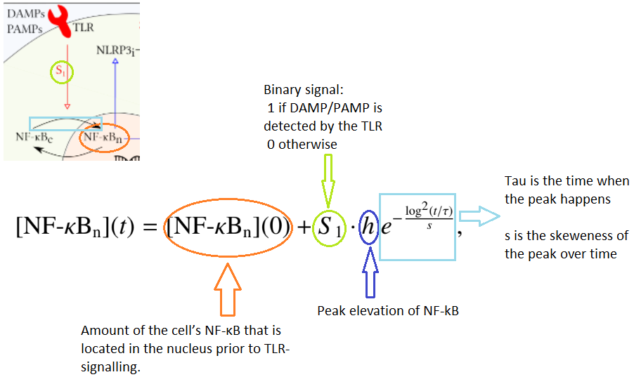

The functions given next represent the mechanics behind the production of NLRP3, and the functions were given in as ODEs. The problem with representing the rates as ODEs is that sometimes it can be hard to determine what are all the terms and what they represent; this is not the case for this set for the NLRP3 molecule as you can see in the on the couple next images.

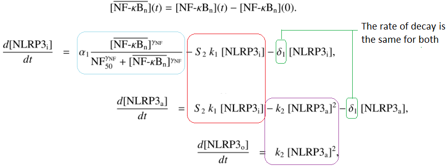

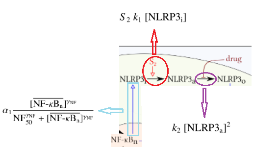

Here I tried to use the colors to show what each of the terms represents in the model, using part of the biological representation digram. As we can see, I also tried to show how each of the terms in each derivative can be represented in a single term. For example, in red, we can see that the second term in the dNLRPi/dt and the first term on the derivative dNLRP3a/dt are the same, and they represent the rate at which the molecule of NLRP3 goes from its inactive form to active. As context for the name of the last NLRP3o is in its oligomerized form.

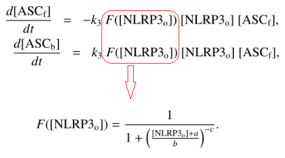

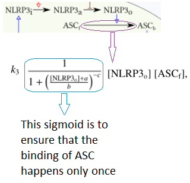

One of the interesting points is how they decided to establish the amount of ASC available is given as a constant the free version of ASC is with the value of one defined as an arbitrary unit.

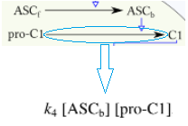

The same happens with the values of pro-C1, which also have a constant unit value of one; only the rate of transforming it to C1 is given.

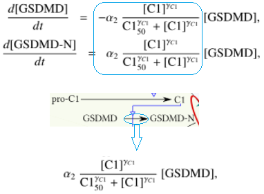

Following the example of the two above molecules, GSDMD is also defined with a constant value of one, and the ODEs describe the rate of change from its initial form to after cleavage caused by C1, or caspase-1.

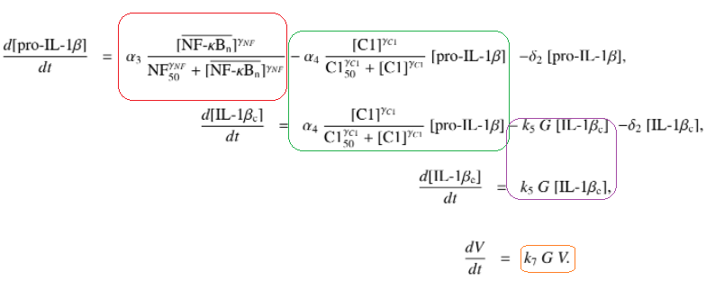

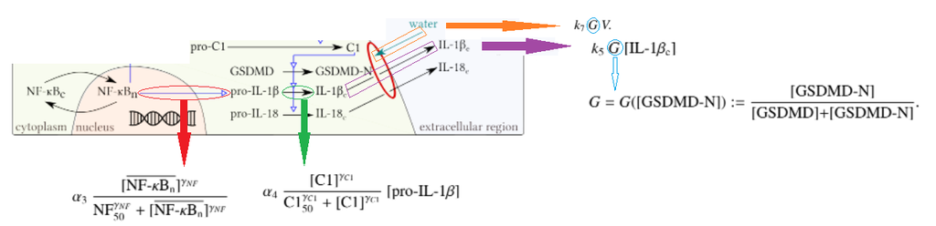

The GSDMD-N molecule creates holes in the cell membrane, which leads to the expelling of IL-1$\beta$ into the medium. This mechanism is to alert cells in the vicinity that something is wrong, and they should also start pyroptosis to make the signal stronger for the immune system to respond faster and as a primitive way to control the spread of the virus to more cells and consequently to produce more viruses. The hole in the membrane also allows liquid from the extracellular environment to enter the cell, which swells the cell, causing a membrane rupture and death.

## Computational model

The next step described in the *Workflow for Developing Mechanism-Based Computational Biology Models* is the development of a computational model using the mathematical representation of the dynamics of each molecule. At this point in our project, we are focused on establishing the rates of the underlying mechanisms using Antimony and Tellurium to simulate those rates, and after the benchmarks for the rates are achieved, we will import the Antimony to CCD3 and give a spatial representation for the model. So, here is the first part of the computational model in Antimony.

```python
import tellurium as te
import numpy as np

r = te.loada('''

    model pyro()

    # Continous Equations
    NF_kBn  := NF_kB0 +  S1 * h * expo;

    log_two := log((T_time / tau));
    expo    := exp(-(log_two^2 / s));
    T_time  := time+1;

    # Equations
    J2_3_1:  -> NLRP3i;  a1 * (((NF_kBn - NF_kB0)^gamma_NF) / (NF_50^gamma_NF + ((NF_kBn - NF_kB0)^gamma_NF)));

    J2_3_2:  NLRP3i -> ;       delta_1 * NLRP3i;

    J2_3_3:  NLRP3i -> NLRP3a; S2 * k1 * NLRP3i;

    J2_4_1:  NLRP3a -> ;       delta_1 * NLRP3a;
    J2_4_2:  NLRP3a -> NLRP3o; k2 * NLRP3a^2;

    J2_8:    ASCf -> ASCb;     k3 * (1 / (1+((NLRP3o + a)/ b )^-c)) * NLRP3o * ASCf;

    J2_13:   pro_C1 -> C1;     k4 * ASCb * pro_C1;

    J2_16:   GSDMD -> GSDMD_N; a2 * ((C1^gamma_C1) / ((C1_50^gamma_C1) + (C1^gamma_C1))) * GSDMD;

    J2_18_1: -> pro_IL_1beta;  a3 * ((NF_kBn - NF_kB0)^gamma_NF / (NF_50^gamma_NF + (NF_kBn - NF_kB0)^gamma_NF));
    J2_18_2: pro_IL_1beta -> ; delta_2 * pro_IL_1beta;

    J2_18_3: pro_IL_1beta -> IL_1betac; a4 * ((C1^gamma_C1) / ((C1_50^gamma_C1) + (C1^gamma_C1))) * pro_IL_1beta;

    J2_19:   IL_1betac -> ;             delta_2 * IL_1betac;
    J2_20:   IL_1betac -> IL_1betae;    k5 * (GSDMD_N / (GSDMD + GSDMD_N)) * IL_1betac;


    J2_23:   pro_IL_18 -> IL_18c;       a5 * ((C1^gamma_C1) / ((C1_50^gamma_C1) + (C1^gamma_C1))) * pro_IL_18;
    J2_24:   IL_18c -> IL_18e;          k6 * (GSDMD_N / (GSDMD + GSDMD_N)) * IL_18c;

    J2_26:   -> Volume;                 k7 * (GSDMD_N / (GSDMD + GSDMD_N)) * Volume;

    # Constant
    a = 1;           # arbitrary units (a.u.)
    b = 2;           # (a.u.)
    c = 1000;

    a1 = 0.07;       # min^-1 (a.u.)
    a2 = 0.1;        # min^-1
    a3 = 0.06;       # min^-1 (a.u.)
    a4 = 1;          # min^-1
    a5 = 1;          # min^-1

    C1_50 = 0.3;     # (a.u.)
    NF_50 = 0.3;     # (a.u.)

    delta_1 = 0.002; # min^-1
    delta_2 = 0.004; # min^-1

    h = 0.55;        # (a.u.)

    gamma_C1 = 2;
    gamma_NF = 2;

    k1 = 0.7;        # min^-1
    k2 = 1;          # min^-1 (a.u.)
    k3 = 0.04;       # min^-1 (a.u.)
    k4 = 0.03;       # min^-1 (a.u.)
    k5 = 1;          # min^-1
    k6 = 1;          # min^-1
    k7 = 0.2;        # min^-1

    n = 1;           # (a.u.)

    s = 0.8;        # (a.u.) paper

    tau = 10;        # min
    Vc = 1.5;        # (a.u.)

    # Species
    S1        = 1;
    S2        = 1;
    NF_kB0    = 0.25;   # (a.u.)
    GSDMD     = 1;      # (a.u.)
    ASCf      = 1;      # (a.u.)
    pro_C1    = 1;      # (a.u.)
    Volume    = 1;      # (a.u.)
    pro_IL_18 = 1;      # (a.u.)

    end

''')
```

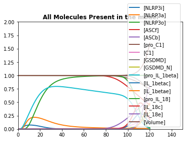

```python
# Concatination of all parameters in one plot
s = r.simulate(0, 120, 1000)
r.plot(ylim=[0.0, 2.0],xlim=[0,150],title="All Molecules Present in the model")
r.show()
r.resetAll()
```

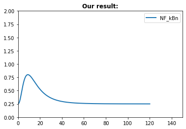

```python
# First plot of the paper p.12
s = r.simulate(0, 120, 1000, ['time','NF_kBn'])
r.plot(ylim=[0.0, 2.0],xlim=[0,150], title="Our result:")
r.show()
r.resetAll()
```

Paper reference:

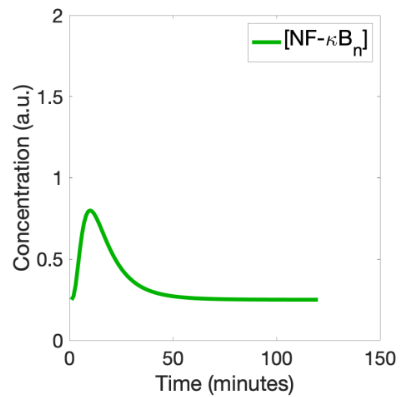

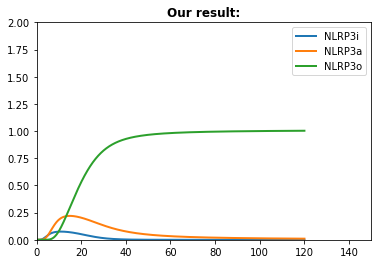

```python
# Second plot of the paper p.12
s = r.simulate(0, 120, 1000, ['time','NLRP3i', 'NLRP3a', 'NLRP3o'])
r.plot(ylim=[0,2.0],xlim=[0,150], title="Our result:")
r.show()
r.resetAll()
```

Paper reference:

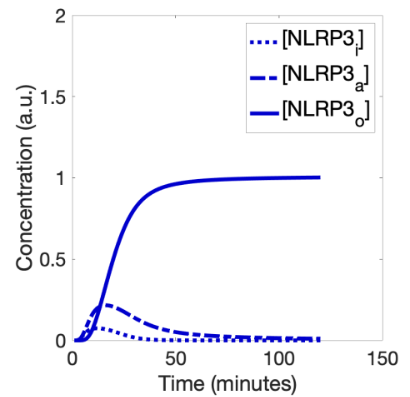

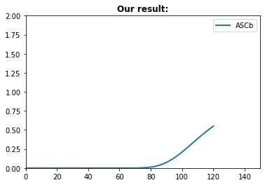

```python
# Third plot of the paper p.12
s = r.simulate(0, 120, 1000, ['time','ASCb'])
r.plot(ylim=[0.0, 2.0],xlim=[0,150], title="Our result:")
r.show()
r.resetAll()
```

Paper reference:

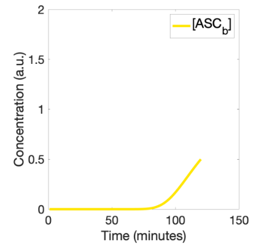

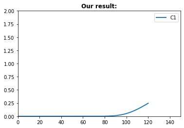

```python
# Fourth plot of the paper p.12
s = r.simulate(0, 120, 1000, ['time', 'C1'])
r.plot(ylim=[0.0, 2.0],xlim=[0,150], title="Our result:")
r.show()
r.resetAll()
```

Paper reference:

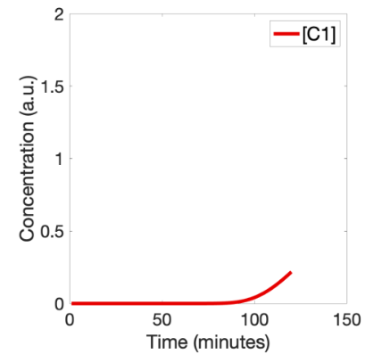

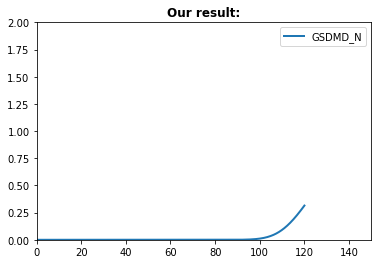

```python
# Fifth plot of the paper p.12
s = r.simulate(0, 120, 1000, ['time', 'GSDMD_N'])
r.plot(ylim=[0.0, 2.0],xlim=[0,150], title="Our result:")
r.show()
r.resetAll()
```

Paper reference:

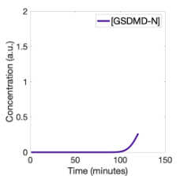

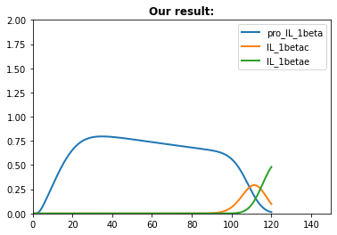

```python
# Sixth plot of the paper p.12
s = r.simulate(0, 120, 1000, ['time','pro_IL_1beta', 'IL_1betac', 'IL_1betae'])
r.plot(ylim=[0.0, 2.0],xlim=[0,150], title="Our result:")
r.show()
r.resetAll()
```

Paper reference:

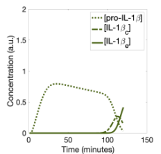

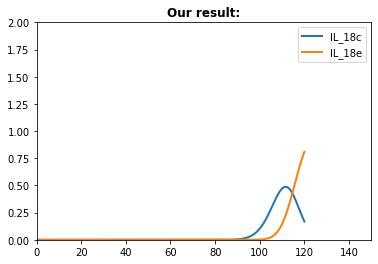

```python
# Seventh plot of the paper p.12
s = r.simulate(0, 120, 1000, ['time', 'IL_18c', 'IL_18e'])
r.plot(ylim=[0.0, 2.0],xlim=[0,150], title="Our result:")
r.show()
r.resetAll()
```

Paper reference:

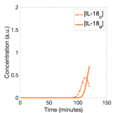

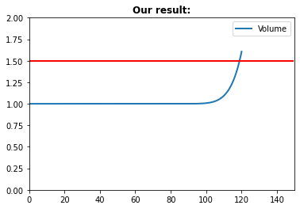

```python
x_axis = np.arange(0, 150)
y_axis = np.full(150, 1.5)

# Eighth plot of the paper p.12
s = r.simulate(0, 120, 1000, ['time','Volume'])
r.plot(ylim=[0.0, 2.0],xlim=[0,150], show=False, title="Our result:")
te.plot(x_axis,y_axis, show=False, color="red")
te.show()
r.resetAll()
```

Paper reference:

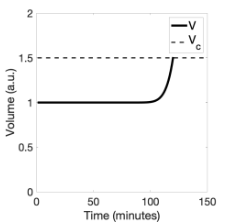

By comparing the graphs, we can see that the replication of the paper using Antimony worked as expected, and now we can transfer this model to CC3D and create a spacial representation for cells being infected and undergoing Pyroptosis.

There is a different challenge to this step since we have to rethink how to integrate the model into a spacial model, similar to thinking about setting up an experiment to focus on the phenomenon we want to observe.

For this model, in particular, we chose to represent four different cell types:

**(Healthy, Pyro_DAMPS, Pyro_IL1beta, Dead_Pyro)**

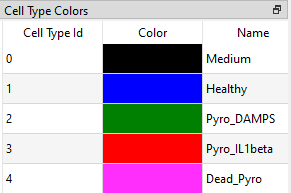

And two different diffusion fields:

(DAMP, IL1B)

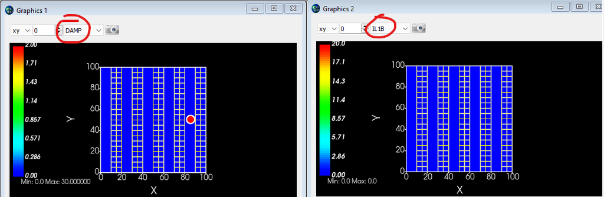

At the beginning of the simulation, all cells are initiated as healthy(blue) cells, meaning they have not commenced pyroptosis. They are also distributed in two cells wide strips, which account for 10 voxels wide and 100 voxels high for each strip. The medium space between each strip is also 10x100, and the boundary conditions for this simulation are periodic, which means that the last strip on the right side of the lattice is connected with the first column of voxels on the left side.

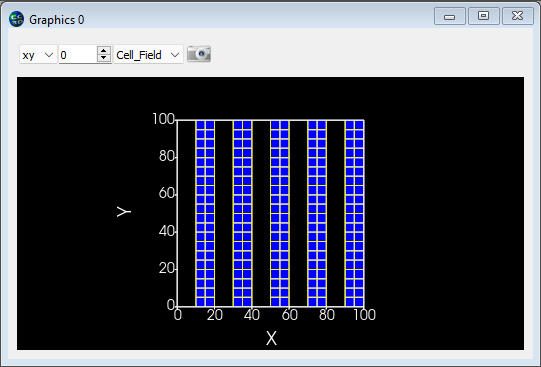

*40 cells per strip x 5 strips = 200 initial cells*

The idea for this type of distribution of cells is to see how neighbor cells are affected and, at the same time, observe the different periods of initiation when cells are further away from the first pyroptotic cell.